\pagebreak

# Handin 1

#### Imports

```python
import scipy.io
import sys
import numpy as np
import networkx as nx
import matplotlib.pyplot as plt
import pandas as pd
import warnings
import matplotlib.cbook
import os
from scipy import sparse
from sklearn.preprocessing import normalize
import operator
import random as rand
```

#### Data Entry

```python
# Data Entry
mat = scipy.io.loadmat('IOdownload.mat')
econ = mat['econ']
io = mat['io']
names = mat['name']

l = []
for n in names:
    s = (n[0][0])
    s = s[2:]
    s = s.strip()
    l.append(s)
names = l

# Removing certain warnings that makes the print outs more ugly. Nothing important really
warnings.simplefilter(action='ignore', category=FutureWarning)
warnings.filterwarnings("ignore",category=matplotlib.cbook.mplDeprecation)
```

```python
swe2000 = io['swe2000'][0][0]
idn2000 = io['idn2000'][0][0]
swemat = pd.DataFrame(swe2000, index = names, columns = names)
idnmat = pd.DataFrame(idn2000, index = names, columns = names)
```

#### UDF for creating directed graphs

```python
# Creates a directed graph with weights using a numpay matrix as input.
def create_directed_graph(mat):
    df = pd.DataFrame(mat)
    edges = get_edges(df)
    G = nx.DiGraph()
    G.add_nodes_from(range(0,len(df)))
    G.add_edges_from(edges)
    return G

# Creates a list with all the edges where all entries are a tuple
# containing the source node, head node and weigth of the node
def get_edges(df):
    n = len(df)
    l = []
    for i in range(0,n):
        for j in range(0,n):
            w = df[j][i]
            if w > 0:
                a = (i,j, {'weight':w})
                l.append(a)
    return l
```

#### Initializing the neworks

```python
# Creates Graphs for the Swedish and Indonesian economy
G_swe = create_directed_graph(swe2000)
G_idn = create_directed_graph(idn2000)
```

```python
np.sum(swe2000[:,0])
```

```
26966.356090133006
```

```python
swemat
```

|  | Agriculture | Mining and quarrying (energy) | Mining and quarrying (non-energy) | Food products | Textiles | Wood and products of wood and cork | Pulp | Coke | Chemicals excluding pharmaceuticals | Pharmaceuticals | ... | Finance & insurance | Real estate activities | Renting of machinery & equipment | Computer & related activities | Research & development | Other Business Activities | Public admin. & defence; compulsory social security | Education | Health & social work | Other community |
| --- | --- | --- | --- | --- | --- | --- | --- | --- | --- | --- | --- | --- | --- | --- | --- | --- | --- | --- | --- | --- | --- |
| Agriculture | 3765.209 | 11.062 | 4.986 | 25678.278 | 131.251 | 13405.920 | 8524.734 | 3.078 | 168.966 | 0.0 | ... | 20.690 | 710.868 | 83.938 | 245.264 | 74.558 | 342.976 | 146.346 | 119.434 | 250.220 | 788.315 |
| Mining and quarrying (energy) | 329.965 | 24.514 | 43.051 | 11.262 | 1.251 | 10.006 | 83.985 | 37402.108 | 452.519 | 0.0 | ... | 0.911 | 28.175 | 9.019 | 83.066 | 1.453 | 48.636 | 3.917 | 1.052 | 5.590 | 10.041 |
| Mining and quarrying (non-energy) | 139.148 | 52.320 | 288.814 | 82.574 | 3.447 | 8.879 | 323.111 | 37.994 | 344.838 | 0.0 | ... | 4.384 | 285.317 | 16.473 | 26.916 | 7.534 | 260.502 | 65.601 | 8.208 | 18.411 | 92.266 |
| Food products | 4581.551 | 14.422 | 12.409 | 25360.862 | 271.990 | 48.738 | 757.765 | 27.487 | 715.862 | 0.0 | ... | 44.513 | 255.552 | 104.266 | 282.766 | 85.488 | 356.442 | 1025.045 | 1142.344 | 2629.148 | 602.473 |
| Textiles | 293.783 | 0.230 | 25.021 | 124.269 | 2807.346 | 32.072 | 361.852 | 10.074 | 83.628 | 0.0 | ... | 38.876 | 123.163 | 35.835 | 187.474 | 76.215 | 381.037 | 740.865 | 218.629 | 1438.245 | 525.346 |
| Wood and products of wood and cork | 353.126 | 13.483 | 62.956 | 216.175 | 81.030 | 6917.837 | 6067.059 | 5.244 | 130.281 | 0.0 | ... | 12.881 | 2258.575 | 83.319 | 258.651 | 78.317 | 892.361 | 196.042 | 129.797 | 73.886 | 936.504 |
| Pulp | 276.495 | 6.646 | 98.434 | 2759.888 | 255.954 | 560.973 | 30764.668 | 62.812 | 1770.877 | 0.0 | ... | 2310.479 | 1673.416 | 503.794 | 5686.038 | 1714.936 | 10419.341 | 2100.199 | 4625.119 | 1694.312 | 3522.560 |
| Coke | 1526.563 | 21.543 | 243.650 | 397.635 | 61.740 | 258.512 | 962.559 | 2742.845 | 2822.793 | 0.0 | ... | 79.295 | 684.586 | 89.560 | 182.233 | 39.481 | 653.869 | 658.953 | 153.269 | 420.455 | 486.436 |
| Chemicals excluding pharmaceuticals | 1725.417 | 14.657 | 267.455 | 1384.222 | 1005.949 | 821.663 | 6770.034 | 886.551 | 19761.862 | 0.0 | ... | 225.625 | 831.908 | 158.187 | 721.422 | 228.682 | 3245.119 | 737.647 | 382.403 | 3414.459 | 1263.017 |
| Pharmaceuticals | 0.000 | 0.000 | 0.000 | 0.000 | 0.000 | 0.000 | 0.000 | 0.000 | 0.000 | 0.0 | ... | 0.000 | 0.000 | 0.000 | 0.000 | 0.000 | 0.000 | 0.000 | 0.000 | 0.000 | 0.000 |
| Rubber & plastics products | 66.426 | 10.584 | 84.261 | 1968.379 | 225.276 | 367.712 | 674.909 | 81.936 | 1237.791 | 0.0 | ... | 123.127 | 529.844 | 106.817 | 963.722 | 239.469 | 1267.435 | 688.029 | 171.802 | 770.009 | 375.799 |
| Other non-metallic mineral products | 292.212 | 12.318 | 288.494 | 406.101 | 63.891 | 527.782 | 184.219 | 34.608 | 489.223 | 0.0 | ... | 16.369 | 1452.655 | 50.675 | 226.276 | 51.952 | 508.140 | 204.907 | 88.230 | 276.526 | 162.470 |
| Iron & steel | 138.350 | 1.625 | 101.565 | 87.057 | 71.314 | 501.469 | 957.894 | 342.455 | 599.018 | 0.0 | ... | 64.205 | 356.884 | 125.817 | 471.010 | 304.176 | 1348.866 | 225.467 | 74.299 | 74.649 | 100.800 |
| Non-ferrous metals | 0.000 | 0.000 | 0.000 | 0.000 | 0.000 | 0.000 | 0.000 | 0.000 | 0.000 | 0.0 | ... | 0.000 | 0.000 | 0.000 | 0.000 | 0.000 | 0.000 | 0.000 | 0.000 | 0.000 | 0.000 |
| Fabricated metal products | 319.299 | 49.983 | 207.297 | 1402.194 | 105.097 | 2664.576 | 373.602 | 352.309 | 589.618 | 0.0 | ... | 71.254 | 1539.036 | 205.963 | 1735.591 | 411.045 | 1753.503 | 1039.213 | 281.729 | 291.052 | 483.024 |
| Machinery & equipment | 3011.862 | 63.040 | 724.130 | 1016.328 | 135.119 | 1118.630 | 2972.997 | 423.084 | 1067.255 | 0.0 | ... | 168.088 | 1083.705 | 811.583 | 1632.874 | 702.983 | 1958.605 | 3904.076 | 301.611 | 266.656 | 619.400 |
| Office | 33.182 | 8.332 | 6.113 | 117.314 | 19.936 | 63.591 | 165.733 | 12.358 | 104.987 | 0.0 | ... | 46.410 | 78.416 | 31.118 | 172.435 | 29.443 | 173.907 | 293.938 | 50.661 | 36.134 | 46.658 |
| Electrical machinery & apparatus | 53.429 | 1.830 | 41.618 | 109.232 | 20.514 | 195.791 | 274.886 | 52.714 | 254.772 | 0.0 | ... | 105.157 | 721.905 | 174.474 | 910.196 | 302.895 | 1192.927 | 642.475 | 200.906 | 266.903 | 334.606 |
| Radio | 196.503 | 3.731 | 45.669 | 317.825 | 32.251 | 142.576 | 602.344 | 46.952 | 459.164 | 0.0 | ... | 187.298 | 774.623 | 163.700 | 1593.637 | 345.224 | 2082.154 | 3148.440 | 211.197 | 415.991 | 426.919 |
| Medical | 28.029 | 0.551 | 6.474 | 52.532 | 6.983 | 19.569 | 108.736 | 50.373 | 190.386 | 0.0 | ... | 39.977 | 245.888 | 44.345 | 229.470 | 145.305 | 1237.095 | 1156.075 | 259.668 | 5205.937 | 421.134 |
| Motor vehicles | 316.034 | 22.008 | 60.864 | 426.221 | 56.352 | 159.191 | 718.857 | 58.987 | 481.232 | 0.0 | ... | 150.145 | 402.575 | 441.928 | 969.264 | 1342.393 | 1954.622 | 777.802 | 204.927 | 301.390 | 573.403 |
| Building & repairing of ships & boats | 115.440 | 0.307 | 20.522 | 24.699 | 2.781 | 37.240 | 52.555 | 6.265 | 33.056 | 0.0 | ... | 64.482 | 603.489 | 156.556 | 144.112 | 63.584 | 258.869 | 4616.289 | 64.089 | 158.584 | 48.261 |
| Aircraft & spacecraft | 0.000 | 0.000 | 0.000 | 0.000 | 0.000 | 0.000 | 0.000 | 0.000 | 0.000 | 0.0 | ... | 0.000 | 0.000 | 0.000 | 0.000 | 0.000 | 0.000 | 0.000 | 0.000 | 0.000 | 0.000 |
| Railroad equipment & transport equip nec. | 0.000 | 0.000 | 0.000 | 0.000 | 0.000 | 0.000 | 0.000 | 0.000 | 0.000 | 0.0 | ... | 0.000 | 0.000 | 0.000 | 0.000 | 0.000 | 0.000 | 0.000 | 0.000 | 0.000 | 0.000 |
| Manufacturing nec; recycling (include Furniture) | 38.616 | 1.199 | 13.785 | 381.201 | 72.722 | 306.661 | 427.311 | 93.844 | 113.536 | 0.0 | ... | 80.526 | 541.126 | 47.951 | 230.959 | 129.269 | 705.800 | 784.545 | 351.375 | 461.116 | 492.709 |
| Production | 651.790 | 31.413 | 387.782 | 864.768 | 132.382 | 726.929 | 4849.358 | 260.328 | 1526.933 | 0.0 | ... | 333.932 | 3399.397 | 131.165 | 216.367 | 117.711 | 709.257 | 1561.813 | 969.687 | 1819.020 | 1658.414 |
| Manufacture of gas; distribution of gaseous fuels through mains | 0.000 | 0.000 | 0.000 | 0.000 | 0.000 | 0.000 | 0.000 | 0.000 | 0.000 | 0.0 | ... | 0.000 | 0.000 | 0.000 | 0.000 | 0.000 | 0.000 | 0.000 | 0.000 | 0.000 | 0.000 |
| Steam and hot water supply | 0.000 | 0.000 | 0.000 | 0.000 | 0.000 | 0.000 | 0.000 | 0.000 | 0.000 | 0.0 | ... | 0.000 | 0.000 | 0.000 | 0.000 | 0.000 | 0.000 | 0.000 | 0.000 | 0.000 | 0.000 |
| Collection | 3.708 | 7.999 | 35.318 | 209.497 | 36.463 | 84.785 | 239.325 | 16.410 | 93.331 | 0.0 | ... | 134.665 | 6049.617 | 13.097 | 36.915 | 28.565 | 79.322 | 575.710 | 105.861 | 528.531 | 418.109 |
| Construction | 1322.559 | 10.116 | 267.632 | 650.318 | 71.854 | 383.230 | 1075.868 | 190.597 | 633.882 | 0.0 | ... | 1217.377 | 30693.832 | 160.163 | 505.390 | 281.240 | 1685.062 | 6639.877 | 1700.042 | 1256.131 | 2422.552 |
| Wholesale & retail trade; repairs | 2806.034 | 36.766 | 418.572 | 3497.180 | 282.148 | 1412.758 | 4555.523 | 314.363 | 1817.048 | 0.0 | ... | 629.094 | 3357.669 | 889.836 | 2299.693 | 637.305 | 4868.145 | 3867.069 | 1468.947 | 3103.195 | 4559.239 |
| Hotels & restaurants | 82.672 | 3.157 | 38.489 | 364.856 | 58.342 | 66.336 | 615.590 | 23.506 | 427.219 | 0.0 | ... | 1183.384 | 1022.085 | 268.339 | 1935.479 | 236.833 | 6156.944 | 1399.141 | 857.260 | 1481.911 | 1950.896 |
| Land transport; transport via pipelines | 301.675 | 171.614 | 882.476 | 4113.633 | 375.576 | 5494.201 | 9491.834 | 250.384 | 2699.050 | 0.0 | ... | 282.032 | 785.999 | 449.033 | 1277.200 | 321.304 | 1959.376 | 2053.887 | 2875.286 | 863.376 | 2259.377 |
| Water transport | 11.228 | 7.963 | 78.198 | 237.265 | 19.587 | 297.676 | 490.273 | 156.284 | 142.316 | 0.0 | ... | 30.197 | 31.416 | 18.791 | 97.360 | 14.071 | 215.277 | 47.660 | 22.359 | 35.740 | 44.479 |
| Air transport | 269.130 | 0.758 | 83.432 | 187.825 | 43.372 | 156.873 | 352.940 | 9.230 | 147.010 | 0.0 | ... | 240.738 | 441.587 | 107.492 | 578.988 | 150.105 | 1495.047 | 1570.672 | 587.251 | 588.843 | 1011.642 |
| Supporting+auxiliary transport activities;travel agencies | 162.330 | 65.748 | 360.574 | 2336.977 | 147.083 | 1621.666 | 3242.045 | 135.629 | 1143.836 | 0.0 | ... | 464.206 | 1193.484 | 281.890 | 1508.002 | 99.936 | 2540.666 | 969.187 | 502.581 | 500.958 | 732.148 |
| Post & telecommunications | 350.971 | 10.905 | 90.280 | 804.221 | 110.461 | 338.761 | 4394.912 | 72.405 | 1160.390 | 0.0 | ... | 3222.623 | 2514.591 | 369.382 | 2922.081 | 277.785 | 6239.570 | 6719.371 | 1123.053 | 1618.814 | 3791.789 |
| Finance & insurance | 1315.888 | 25.540 | 221.225 | 1123.944 | 142.182 | 1319.052 | 2460.944 | 440.434 | 1128.525 | 0.0 | ... | 12184.885 | 14457.673 | 254.893 | 1106.332 | 184.273 | 2559.622 | 2259.352 | 302.552 | 369.740 | 2660.529 |
| Real estate activities | 62.528 | 14.291 | 67.612 | 842.703 | 42.771 | 265.748 | 2034.320 | 80.301 | 468.048 | 0.0 | ... | 5728.661 | 14309.347 | 1126.206 | 3141.895 | 1591.775 | 8879.230 | 12965.831 | 13128.471 | 17806.518 | 6577.760 |
| Renting of machinery & equipment | 90.335 | 5.381 | 39.397 | 160.651 | 51.622 | 192.414 | 674.470 | 6.254 | 142.497 | 0.0 | ... | 248.922 | 187.858 | 108.779 | 407.171 | 61.550 | 1118.129 | 422.500 | 163.624 | 185.918 | 495.281 |
| Computer & related activities | 138.039 | 7.722 | 96.088 | 707.365 | 152.162 | 254.638 | 856.119 | 114.179 | 1714.546 | 0.0 | ... | 1626.091 | 868.824 | 841.192 | 6894.332 | 299.323 | 10670.522 | 3447.681 | 622.906 | 991.461 | 1165.337 |
| Research & development | 21.668 | 8.746 | 119.652 | 241.483 | 50.870 | 31.721 | 840.973 | 32.339 | 997.416 | 0.0 | ... | 61.673 | 118.190 | 60.094 | 406.390 | 660.066 | 1182.399 | 522.177 | 218.049 | 72.721 | 747.712 |
| Other Business Activities | 1023.972 | 77.547 | 671.546 | 6119.928 | 555.201 | 1880.550 | 8465.515 | 546.974 | 9782.481 | 0.0 | ... | 9378.049 | 7359.309 | 1845.292 | 13136.186 | 1520.034 | 39090.862 | 12548.124 | 2797.798 | 5346.990 | 8799.191 |
| Public admin. & defence; compulsory social security | 273.846 | 22.101 | 83.630 | 531.645 | 77.869 | 410.756 | 880.483 | 104.420 | 791.846 | 0.0 | ... | 1125.453 | 1812.668 | 182.075 | 830.334 | 229.849 | 2045.863 | 3547.250 | 5509.923 | 7325.016 | 1853.280 |
| Education | 29.785 | 3.885 | 11.836 | 169.968 | 28.459 | 113.074 | 508.183 | 88.261 | 83.260 | 0.0 | ... | 564.062 | 370.608 | 170.861 | 1411.981 | 193.988 | 2015.292 | 2730.727 | 1643.963 | 1073.691 | 582.749 |
| Health & social work | 302.187 | 2.593 | 14.695 | 104.287 | 22.835 | 56.188 | 212.263 | 6.230 | 101.857 | 0.0 | ... | 138.431 | 252.830 | 38.552 | 206.311 | 128.881 | 614.900 | 875.733 | 983.805 | 4093.974 | 692.441 |
| Other community | 145.369 | 6.188 | 44.925 | 419.241 | 118.944 | 295.683 | 3777.681 | 57.131 | 289.089 | 0.0 | ... | 588.587 | 7966.459 | 263.526 | 1038.535 | 156.607 | 9975.256 | 977.428 | 673.225 | 1996.314 | 6606.719 |

47 rows × 47 columns

#### Data Familiarization

```python
print('|----------------------------------------------------------|')
print('               There are ' + str(len(G_swe.edges())) + ' edges in G_swe')
print('               There are ' + str(len(G_swe.nodes())) + ' nodes in G_swe')
print('|----------------------------------------------------------|')

print('|----------------------------------------------------------|')
print('               There are ' + str(len(G_idn.edges())) + ' edges in G_idn')
print('               There are ' + str(len(G_idn.nodes())) + ' nodes in G_idn')
print('|----------------------------------------------------------|')
```

```
|----------------------------------------------------------|
               There are 1681 edges in G_swe
               There are 47 nodes in G_swe
|----------------------------------------------------------|
|----------------------------------------------------------|
               There are 2025 edges in G_idn
               There are 47 nodes in G_idn
|----------------------------------------------------------|
```

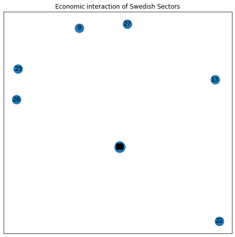

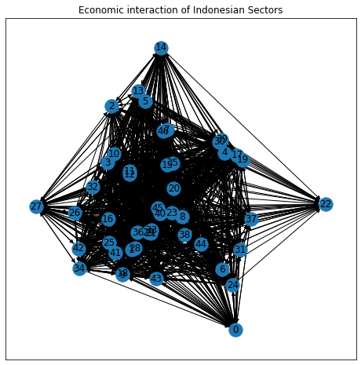

```python
# Plots the networks below
plt.figure(1, figsize = (8,8))
nx.draw_networkx(G_swe)
plt.title('Economic interaction of Swedish Sectors')
plt.show()

plt.figure(2, figsize = (8,8))
nx.draw_networkx(G_idn)
plt.title('Economic interaction of Indonesian Sectors')
plt.show()
```

The Swedish graph looks disconnected while the Indonesian looks connected.

```python
print('Adjecency Matrix for Sweden')
display(swemat.head(5))
print('Adjecency Matrix for Indonesia')
display(idnmat.head(5))
```

```
Adjecency Matrix for Sweden
```

|  | Agriculture | Mining and quarrying (energy) | Mining and quarrying (non-energy) | Food products | Textiles | Wood and products of wood and cork | Pulp | Coke | Chemicals excluding pharmaceuticals | Pharmaceuticals | ... | Finance & insurance | Real estate activities | Renting of machinery & equipment | Computer & related activities | Research & development | Other Business Activities | Public admin. & defence; compulsory social security | Education | Health & social work | Other community |
| --- | --- | --- | --- | --- | --- | --- | --- | --- | --- | --- | --- | --- | --- | --- | --- | --- | --- | --- | --- | --- | --- |
| Agriculture | 3765.209 | 11.062 | 4.986 | 25678.278 | 131.251 | 13405.920 | 8524.734 | 3.078 | 168.966 | 0.0 | ... | 20.690 | 710.868 | 83.938 | 245.264 | 74.558 | 342.976 | 146.346 | 119.434 | 250.220 | 788.315 |
| Mining and quarrying (energy) | 329.965 | 24.514 | 43.051 | 11.262 | 1.251 | 10.006 | 83.985 | 37402.108 | 452.519 | 0.0 | ... | 0.911 | 28.175 | 9.019 | 83.066 | 1.453 | 48.636 | 3.917 | 1.052 | 5.590 | 10.041 |
| Mining and quarrying (non-energy) | 139.148 | 52.320 | 288.814 | 82.574 | 3.447 | 8.879 | 323.111 | 37.994 | 344.838 | 0.0 | ... | 4.384 | 285.317 | 16.473 | 26.916 | 7.534 | 260.502 | 65.601 | 8.208 | 18.411 | 92.266 |
| Food products | 4581.551 | 14.422 | 12.409 | 25360.862 | 271.990 | 48.738 | 757.765 | 27.487 | 715.862 | 0.0 | ... | 44.513 | 255.552 | 104.266 | 282.766 | 85.488 | 356.442 | 1025.045 | 1142.344 | 2629.148 | 602.473 |
| Textiles | 293.783 | 0.230 | 25.021 | 124.269 | 2807.346 | 32.072 | 361.852 | 10.074 | 83.628 | 0.0 | ... | 38.876 | 123.163 | 35.835 | 187.474 | 76.215 | 381.037 | 740.865 | 218.629 | 1438.245 | 525.346 |

5 rows × 47 columns

```
Adjecency Matrix for Indonesia
```

|  | Agriculture | Mining and quarrying (energy) | Mining and quarrying (non-energy) | Food products | Textiles | Wood and products of wood and cork | Pulp | Coke | Chemicals excluding pharmaceuticals | Pharmaceuticals | ... | Finance & insurance | Real estate activities | Renting of machinery & equipment | Computer & related activities | Research & development | Other Business Activities | Public admin. & defence; compulsory social security | Education | Health & social work | Other community |
| --- | --- | --- | --- | --- | --- | --- | --- | --- | --- | --- | --- | --- | --- | --- | --- | --- | --- | --- | --- | --- | --- |
| Agriculture | 1.748e+07 | 6.618e+03 | 1.295e+04 | 1.084e+08 | 8.143e+06 | 1.045e+07 | 875058.40 | 7.099e+01 | 1.346e+06 | 543841.100 | ... | 9.651 | 47.301 | 7240.085 | 7240.304 | 5715.105 | 19426.460 | 8165.198 | 87625.93 | 2.070e+06 | 2.970e+05 |
| Mining and quarrying (energy) | 1.287e+04 | 3.743e+07 | 2.896e+04 | 1.069e+05 | 1.643e+05 | 4.849e+04 | 76928.80 | 3.105e+07 | 1.876e+07 | 8482.276 | ... | 1011.399 | 649.437 | 985.712 | 572.319 | 1149.798 | 1079.369 | 6514.489 | 38861.66 | 2.742e+02 | 3.170e+02 |
| Mining and quarrying (non-energy) | 1.155e+02 | 3.274e+03 | 4.343e+06 | 7.289e+04 | 1.682e+03 | 3.628e+04 | 12024.86 | 1.892e+04 | 3.946e+06 | 8240.004 | ... | 0.000 | 0.000 | 0.000 | 32.041 | 0.000 | 0.000 | 0.000 | 321926.70 | 7.593e+00 | 3.931e+00 |
| Food products | 1.931e+07 | 8.036e-06 | 0.000e+00 | 4.957e+07 | 1.557e+06 | 1.423e+05 | 236419.30 | 1.060e+02 | 8.725e+05 | 224645.800 | ... | 10878.710 | 67127.500 | 11926.480 | 8159.075 | 5122.832 | 15762.560 | 8.628 | 0.00 | 2.447e+06 | 2.273e+06 |
| Textiles | 6.290e+04 | 1.656e+04 | 1.209e+04 | 8.454e+04 | 3.857e+07 | 7.233e+04 | 39023.04 | 7.249e+00 | 1.310e+05 | 2323.955 | ... | 5165.269 | 17634.950 | 20442.360 | 18608.830 | 23856.820 | 36120.190 | 99316.120 | 223953.60 | 3.745e+04 | 7.301e+05 |

5 rows × 47 columns

# 1 Centrality in Input-Output Network of Goods

In degree and out degree centrality

### UDFs

#### Computational Algorithms

```python
# Returns the eigenvecotor centrality of the lcc of the input df.
def get_eigenvector_centrality_lcc(df):
    (df, missing_names)= get_LCC(df)
    names_remain = list(df.index.values)
    temp_names = names_remain + missing_names
    m = df.as_matrix()
    (val, vec) = np.linalg.eig(np.transpose(m))


    eigenvector_centrality = list(np.abs(vec[:,0]).flatten())
    eigenvector_centrality= eigenvector_centrality+(list(np.zeros(len(missing_names))))
    df_T = pd.DataFrame(data = eigenvector_centrality, columns = ['Eigenvector Centrality'])
    df_T['Sector'] = temp_names
    return df_T

# return a df over the lcc of the input df as well.
# the names of those sectors that are not included in the largest connecting component.
def get_LCC(df):
    names = list(df.index.values)
    lcc = list(find_LCC(df))

    # This next part is only for us to get the names of the nodes we want to remove from the input df
    a = [x for x in range(lcc[0], lcc[-1] + 1)]
    lcc = set(lcc)
    missing_i = list(lcc ^ set(a))
    missing_names = []
    for i in missing_i:
        temp = names[i]
        missing_names.append(temp)
    df = df.drop(index = missing_names, columns = missing_names) # Remove the nodes that are "missing" that is, those that are not in the lcc.
    return df, missing_names

# Returns the index of the nodes that make up the largest connecting component.
def find_LCC(df):
    temp_mat = df.as_matrix()
    temp_G = nx.from_numpy_matrix(temp_mat)
    return max(nx.connected_components(temp_G))
```

```python
# All of these are rather self explainatory
def get_degree_centrality(df):
    in_degree_centrality = df.sum(axis=1)
    out_degree_centrality = df.sum(axis=0)
    return in_degree_centrality, out_degree_centrality

def get_normalized_centrality(df, s):
    df = df.sort_values(ascending = False) / np.sum(df)
    df = pd.DataFrame(data=df)
    df = df.reset_index()
    df.index = df.index+1
    df.columns=['Sector',s]
    return df

def sort_centralities(df,s):
    df = df.sort_values(ascending = False)
    df = pd.DataFrame(data=df)
    df = df.reset_index()
    df.index = df.index+1
    df.columns=['Sector',s]
    return df

def merge(df1, df2):
    s = df1.columns[0]
    nd = df1.merge(df2, on=[s])
    return nd

# Get in and out degree centralities
def get_degree_centralities(df):
    (in_degree_centrality, out_degree_centrality) = get_degree_centrality(df)
    df_in_degree = sort_centralities(in_degree_centrality,'In degree Centralities')
    df_out_degree = sort_centralities(out_degree_centrality,'Out degree Centralities')
    degree_centrality = merge(df_in_degree, df_out_degree)
    return degree_centrality

# Get in and out degree centralities normalized
def get_degree_centralities_normalized(df):
    (in_degree_centrality, out_degree_centrality) = get_degree_centrality(df)
    in_degree_centrality_normalized = get_normalized_centrality(in_degree_centrality,'In Degree Centrality Normalized')
    out_degree_centrality_normalized = get_normalized_centrality(out_degree_centrality, 'Out Degree Centrality Normalized')
    degree_centrality = merge(in_degree_centrality_normalized, out_degree_centrality_normalized)
    return degree_centrality
```

```python
# Returns the in-degree, out-degree and eigenvecotor centralities for a input df. norm is a boolean that if
# put to true normalizes the value before returning them. Retruns the df sorted by sector
# based on in-degree-centrality.
def get_degree_eigen(df, norm = True):
    eigenvector_centrality = get_eigenvector_centrality_lcc(df)
    if norm is False:
        degree_centrality = get_degree_centralities(df)
    else:
        degree_centrality= get_degree_centralities_normalized(df)
        div = np.sum(list(eigenvector_centrality['Eigenvector Centrality']))
        eigenvector_centrality['Eigenvector Centrality'] = eigenvector_centrality['Eigenvector Centrality'] / div
        eigenvector_centrality = eigenvector_centrality.rename(columns = {'Eigenvector Centrality': 'Eigenvector Centrality Normalized'})

    all_centralities = merge(degree_centrality, eigenvector_centrality)
    return all_centralities
```

```python
# Returns the Katz centrality. mu is assumed to be a uniform n*1 vector with the value 1 everywhere if we don't
# choose to assaign one on our own.
def katz_centrality(G, beta=0.15, mu = 0, norm = False):

    if mu is 0:
        mu = np.ones((len(G), 1))
    return katz_centrality_helper(G, beta, mu, norm)

# For us to have default case for mu we use this helper function.
def katz_centrality_helper(G, beta, mu, norm):
    adj_matrix = nx.to_numpy_matrix(G)
    lambda_w = np.round(np.real(max((np.linalg.eig(adj_matrix))[0])),0)
    alpha = (1-beta)/lambda_w
    katz = (np.linalg.inv(np.eye(len(adj_matrix)) -alpha *np.transpose(adj_matrix)).dot(mu)*beta).tolist()
    flat_list = [item for sublist in katz for item in sublist]
    if norm is True:
        div = sum(flat_list)
        flat_list = [x / div for x in flat_list]
    return flat_list
```

```python
# Returns the katz centralities specified in the assaignment.
def get_katz(df):
    mat = df.values
    G = create_directed_graph(mat)
    names = list(swemat.index.values)
    katz1 = katz_centrality(G, beta = 0.15)
    katz1_norm = katz_centrality(G, beta = 0.15, norm = True)

    # Wholesale entry is on the 30th row, we put that to one and all other entries in mu to zero.
    mu = np.zeros((len(G), 1))
    mu[30,] = 1

    katz2 = katz_centrality(G, mu = mu, beta = 0.15)
    katz2_norm = katz_centrality(G, mu = mu, beta = 0.15, norm = True)

    katz = pd.DataFrame({'Sector': names, 'Katz Centrality': katz1, 'Katz Centrality, mu = [0...0 1 0...0]': katz2, 'Katz Centrality Normalized': katz1_norm, 'Katz Centrality, mu = [0...0 1 0...0] Normalized': katz2_norm})
    return katz
```

#### Print Functions

```python
# Print function for top centralities taking as input:
# mat - a numpy matrix
# n - the number of centralities to be printed
# precision - the number of decimals to use in the printout

def print_top_centralities(mat,n=3,precision=3):

    # giving us a index of length n starting from 1, looks more neet
    i = list(range(1,n+1))

    # in, out and eigen
    df = get_degree_eigen(mat)
    top_3_in = df[['Sector', 'In Degree Centrality Normalized']].sort_values(by=['In Degree Centrality Normalized'], ascending=False).head(n)
    top_3_in.index = i
    top_3_out = df[['Sector', 'Out Degree Centrality Normalized']].sort_values(by=['Out Degree Centrality Normalized'], ascending=False).head(n)
    top_3_out.index = i
    top_3_eig = df[['Sector', 'Eigenvector Centrality Normalized']].sort_values(by=['Eigenvector Centrality Normalized'], ascending=False).head(n)
    top_3_eig.index = i

    # Top Katz
    df = get_katz(mat)
    top_3_katz = df[['Sector', 'Katz Centrality Normalized']].sort_values(by=['Katz Centrality Normalized'], ascending=False).head(n)
    top_3_katz.index = i
    top_3_katz_mu = df[['Sector', 'Katz Centrality, mu = [0...0 1 0...0] Normalized']].sort_values(by=['Katz Centrality, mu = [0...0 1 0...0] Normalized'], ascending=False).head(n)
    top_3_katz_mu = top_3_katz_mu.rename(columns = {'Katz Centrality, mu = [0...0 1 0...0] Normalized': 'Katz Centrality Normalized'})
    top_3_katz_mu.index = i

    # Adjusting the pandas printout settings according to the input.
    pd.set_option('precision', precision)
    pd.set_option('colheader_justify', 'left')
    pd.set_option('display.max_colwidth', -1)

    #Prints
    print('Three Most Central Secotrs According to the In-Degree Centrality')
    print(top_3_in)
    print('\n')

    print('Three Most Central Secotrs According to the Out-Degree Centrality')
    print(top_3_out)
    print('\n')

    print('Three Most Central Secotrs According to the Eigenvector Centrality')
    print(top_3_eig)
    print('\n')

    print('Three Most Central Secotrs According to the Katz Centrality')
    print(top_3_katz)
    print('\n')

    print('Three Most Central Secotrs According to the Katz Centrality With Non-Uniform mu')
    print(top_3_katz_mu)
    print('\n')
```

# 1. Results

```python
## Prints the in., out. and eigen. centralities for the Swedish economy. Adjust printout using head
print('Centrality measurments for the Swedish market')
get_degree_eigen(swemat).head(5)
```

```
Centrality measurments for the Swedish market
```

|  | Sector | In Degree Centrality Normalized | Out Degree Centrality Normalized | Eigenvector Centrality Normalized |
| --- | --- | --- | --- | --- |
| 0 | Other Business Activities | 0.124 | 0.065 | 0.077 |
| 1 | Real estate activities | 0.055 | 0.054 | 0.045 |
| 2 | Wholesale & retail trade; repairs | 0.051 | 0.050 | 0.062 |
| 3 | Pulp | 0.049 | 0.054 | 0.048 |
| 4 | Land transport; transport via pipelines | 0.041 | 0.026 | 0.020 |

```python
## Prints the in., out. and eigen. centralities for the Indonesian economy. Adjust printout using head
print('Centrality measurments for the Indonesian market')
get_degree_eigen(idnmat).head(5)
```

```
Centrality measurments for the Indonesian market
```

|  | Sector | In Degree Centrality Normalized | Out Degree Centrality Normalized | Eigenvector Centrality Normalized |
| --- | --- | --- | --- | --- |
| 0 | Wholesale & retail trade; repairs | 0.136 | 0.087 | 1.775e-02 |
| 1 | Agriculture | 0.134 | 0.048 | 1.418e-01 |
| 2 | Mining and quarrying (energy) | 0.084 | 0.031 | 7.058e-04 |
| 3 | Food products | 0.078 | 0.164 | 4.721e-01 |
| 4 | Chemicals excluding pharmaceuticals | 0.057 | 0.032 | 9.303e-03 |

```python
## Prints the katz centralities for the Swedish economy. Adjust printout using head
print('SWEDEN')
get_katz(swemat).head(5)
```

```
SWEDEN
```

|  | Sector | Katz Centrality | Katz Centrality, mu = [0...0 1 0...0] | Katz Centrality Normalized | Katz Centrality, mu = [0...0 1 0...0] Normalized |
| --- | --- | --- | --- | --- | --- |
| 0 | Agriculture | 0.376 | 1.335e-02 | 0.014 | 1.172e-02 |
| 1 | Mining and quarrying (energy) | 0.157 | 3.269e-04 | 0.006 | 2.872e-04 |
| 2 | Mining and quarrying (non-energy) | 0.205 | 2.816e-03 | 0.007 | 2.473e-03 |
| 3 | Food products | 0.818 | 3.120e-02 | 0.030 | 2.741e-02 |
| 4 | Textiles | 0.201 | 2.219e-03 | 0.007 | 1.949e-03 |

```python
## Prints the katz centralities for the Indonesian economy. Adjust printout using head
print('INDONESIA')
get_katz(idnmat).head(5)
```

```
INDONESIA
```

|  | Sector | Katz Centrality | Katz Centrality, mu = [0...0 1 0...0] | Katz Centrality Normalized | Katz Centrality, mu = [0...0 1 0...0] Normalized |
| --- | --- | --- | --- | --- | --- |
| 0 | Agriculture | 1.013 | 0.126 | 0.067 | 0.099 |
| 1 | Mining and quarrying (energy) | 0.257 | 0.002 | 0.017 | 0.001 |
| 2 | Mining and quarrying (non-energy) | 0.188 | 0.004 | 0.012 | 0.003 |
| 3 | Food products | 3.017 | 0.440 | 0.199 | 0.344 |
| 4 | Textiles | 0.654 | 0.059 | 0.043 | 0.047 |

```python
# Prints the three most central sectors for Sweden based on the in., out., eigen and katz centrality
print('Three Most Central Sectors For Sweden \n --------------------------------------')
print_top_centralities(swemat,3)
```

```
Three Most Central Sectors For Sweden
 --------------------------------------
Three Most Central Secotrs According to the In-Degree Centrality
  Sector                              In Degree Centrality Normalized
1  Other Business Activities          0.124
2  Real estate activities             0.055
3  Wholesale & retail trade; repairs  0.051


Three Most Central Secotrs According to the Out-Degree Centrality
  Sector                      Out Degree Centrality Normalized
1  Radio                      0.068
2  Motor vehicles             0.068
3  Other Business Activities  0.065


Three Most Central Secotrs According to the Eigenvector Centrality
  Sector                      Eigenvector Centrality Normalized
1  Motor vehicles             0.118
2  Radio                      0.098
3  Other Business Activities  0.077


Three Most Central Secotrs According to the Katz Centrality
  Sector                      Katz Centrality Normalized
1  Motor vehicles             0.081
2  Radio                      0.073
3  Other Business Activities  0.062


Three Most Central Secotrs According to the Katz Centrality With Non-Uniform mu
  Sector                              Katz Centrality Normalized
1  Wholesale & retail trade; repairs  0.182
2  Motor vehicles                     0.095
3  Radio                              0.079
```

```python
# Prints the three most central sectors for Indonesia based on the in., out., eigen and katz centrality
print('Three Most Central Sectors For Indonesia \n --------------------------------------')
print_top_centralities(idnmat,3)
```

```
Three Most Central Sectors For Indonesia
 --------------------------------------
Three Most Central Secotrs According to the In-Degree Centrality
  Sector                              In Degree Centrality Normalized
1  Wholesale & retail trade; repairs  0.136
2  Agriculture                        0.134
3  Mining and quarrying (energy)      0.084


Three Most Central Secotrs According to the Out-Degree Centrality
  Sector                              Out Degree Centrality Normalized
1  Food products                      0.164
2  Construction                       0.115
3  Wholesale & retail trade; repairs  0.087


Three Most Central Secotrs According to the Eigenvector Centrality
  Sector                 Eigenvector Centrality Normalized
1  Food products         0.472
2  Hotels & restaurants  0.143
3  Agriculture           0.142


Three Most Central Secotrs According to the Katz Centrality
  Sector                 Katz Centrality Normalized
1  Food products         0.199
2  Hotels & restaurants  0.067
3  Agriculture           0.067


Three Most Central Secotrs According to the Katz Centrality With Non-Uniform mu
  Sector                              Katz Centrality Normalized
1  Food products                      0.344
2  Wholesale & retail trade; repairs  0.147
3  Hotels & restaurants               0.116
```

The resulats for exercise 1 seems reasonable. For both the Swedish and Indonesian economy, the eigenvector centrality and katz centrality with unifrom mu, have the same ranking order (but with different centralities values). This is in accordance with our expectation and the theory.

## 2 Influence on Twitter

#### Data Entry

```python
twitter_mat = scipy.io.loadmat('twitter.mat')
users_mat = scipy.io.loadmat('users.mat')
```

```python
twitter = twitter_mat['twitter']
twitter = pd.DataFrame(twitter, columns = ['i', 'j', 'weight'])

users = users_mat['users']
l = users.tolist()
users_flat = [item for sublist in l for item in sublist]
users = pd.DataFrame({'Users ID' : users_flat},)
users.index = users.index +1
```

```python
twitter = twitter_mat['twitter']
```

#### Computational Algorithms

```python
# Did not get this to work, need to look up further. pageRank_helper does the trick but would be nice to have this one
def pageRank(mat, beta=0.15, mu=0, tol=1e-06):
    n = mat.shape[0]
    if mu is 0:
        mu = np.ones((n,1))
        print(len(mu))
    return pageRank_helper(mat, beta, mu, tol)

def pageRank_helper(mat, beta, mu, tol):
    sparse_matrix = sparse.csr_matrix(mat)
    P = normalize(sparse_matrix, axis=1, norm='l1')
    P_t = np.transpose(P)
    n = P_t.shape[0]
    z = np.zeros((n,1))
    Ps = (sparse.csr_matrix(np.eye(n)))
    k = 0
    dz = beta*mu
    z = z + dz
    while np.linalg.norm(dz) > tol:
        k = k+1
        Ps = P_t*Ps
        dz = beta*np.power((1-beta),k)*Ps*mu
        z = z + dz
    return list(np.squeeze(np.asarray(z)))
```

```python
#Making the Sparse matrix
row = twitter[:,0]
col = twitter[:,1]
data = twitter[:,2]
sparse_matrix = sparse.csr_matrix((data, (row, col)))

#Zero padding to make the sparse matrix quadratic
d = max(row) - max(col)
i = m_r + 1

a = sparse_matrix.toarray()
z = np.zeros((i,d))
quadratic_m = np.concatenate((a, z), axis =1) #The quadratic, AT LAST! :)
```

```python
# Parameters
n = P_t.shape[0]
mu = np.ones((n,1))

#Returns the pageRank Scores for the nodes. Will sparse the matrix inside the function.
page_rank_scores = pageRank_helper(quadratic_m, 0.15, mu, 1e-03)

#This Part returns the top n central nodes in df
indexed = list(enumerate(page_rank_scores))
top_5 = sorted(indexed, key=operator.itemgetter(1))[-5:]
t = list(reversed([i for i, v in top_5]))
df = pd.DataFrame(top_5[::-1], columns = ['node', 'Page Rank'])
df = df.set_index('node')

# Matching the most central nodes to their user ID.
top_five_users = users.loc[t]
top_five_users['Page Rank Score'] = np.round(df['Page Rank'],3)

#Printing out the top 5 users
pd.set_option('precision', 7)
print('The five most central users according to pageRank, with beta = 0.15 \n ------------------------------------------')
print(top_five_users)
```

```
The five most central users according to pageRank, with beta = 0.15
 ------------------------------------------
     Users ID      Page Rank Score
2    99123165.0    122.450
1    876641.0      107.755
112  483996827.0   82.137
9    1128920917.0  70.985
26   4417595361.0  62.684
```

### Discrete-time consensus algorithm with two stubborn nodes

#### UDFs

```python
def average_dynamics(stubborn, u, P, niter=10):
    n = P[0].shape[1]
    # Get Reular Column
    regular = [*range(0,n)]
    for i in stubborn:
        regular.remove(i)

    # Get Q
    Q = P[regular, :][:, regular]
    E = P[regular, :][:, stubborn]

    x = np.zeros((n,niter))

    for i in range(0,len(stubborn)):
        x[stubborn[i]][0] = u[i]

    for i in range(1,niter):
        x_reg = x[regular,i-1]
        x_reg = x_reg.reshape(-1,1)
        x_stub = x[stubborn,i-1]
        x_stub = x_stub.reshape(-1,1)
        a = Q.dot(x_reg).flatten('F') + E.dot(x_stub).flatten('F')
        x[regular,i] = a
        x[stubborn, i] = x[stubborn,i-1]
    #averaging_dynamics = x[:,-1].tolist()
    return x

def pick_samples(df, df_r, n_1, n_2,Tot_rand =False):
    sample = []
    if Tot_rand is True:
        indexed = list(enumerate(df_r))
        bot = list([i for i, v in indexed])
        sample = rand.choices(bot, k=n_2)
    else:
        indexed = list(enumerate(df_r))
        top = sorted(indexed, key=operator.itemgetter(1))[-n_1:]
        bot = sorted(indexed, key=operator.itemgetter(1))[:n_1]
        top = list([i for i, v in top])
        bot = list([i for i, v in bot])
        sampling_top = rand.choices(top, k=n_2)
        sampling_bottom = rand.choices(bot, k=n_2)
        sample = sampling_top + sampling_bottom
    sample = list(set(sample + stubborn))
    return df[sample]
```

## 2. Results

```python
# Choose the number of iterations, the stubborn nodes and their values.
niter = 30
stubborn = [2, 112]
u = [1,-1]
averaging_dynamics_time_series = average_dynamics(stubborn, u, P,niter)
averaging_dynamics_results = averaging_dynamics_time_series[:,-1].tolist()
```

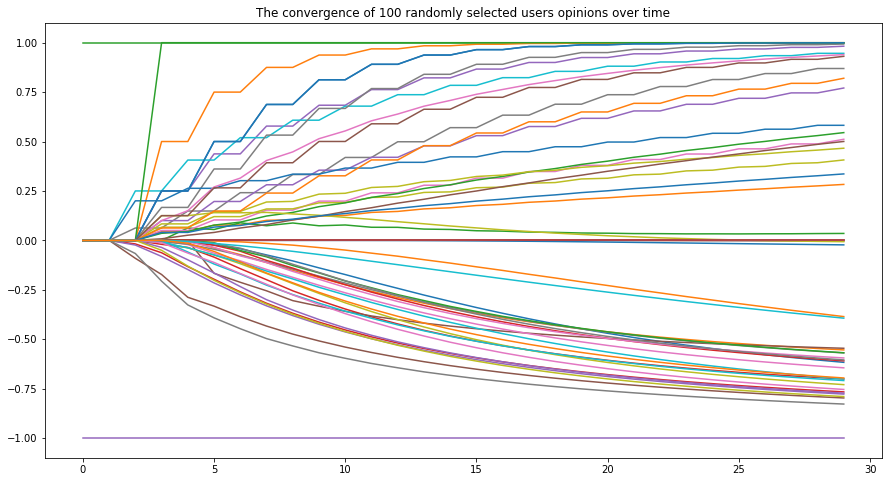

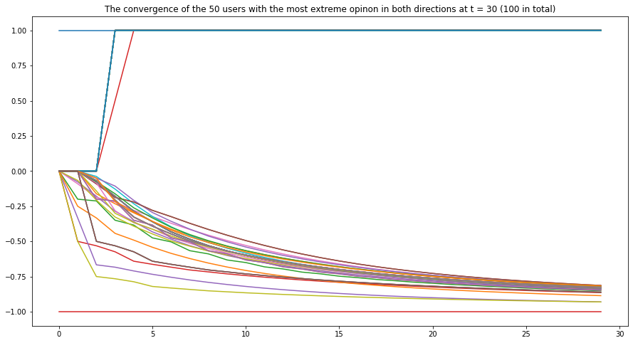

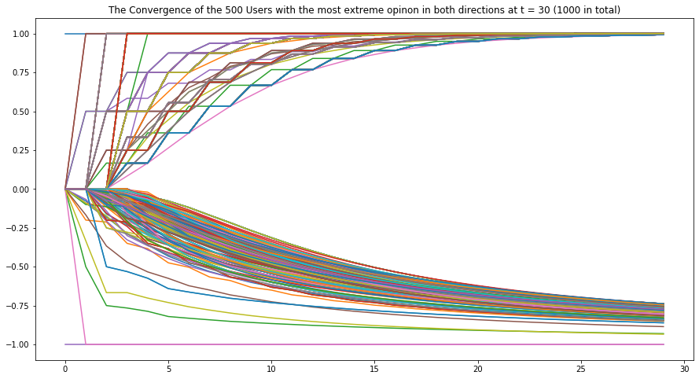

```python
# Picks some random or specified users from the averaging dynamics time series and plots how their
# opinions change with time
d_100_top_bot = pick_samples(averaging_dynamics_time_series, averaging_dynamics_results, 50, 50)
d_100_rand_top_bot = pick_samples(averaging_dynamics_time_series, averaging_dynamics_results, 500, 500)
d_100_rand = pick_samples(averaging_dynamics_time_series, averaging_dynamics_results, 0, 50,True)

plt.figure(1, figsize = (15,8))
plt.plot(np.arange(0, 30), d_100_rand.transpose())
plt.title('The convergence of 100 randomly selected users opinions over time')

plt.figure(2, figsize = (15,8))
plt.plot(np.arange(0, 30), d_100_top_bot.transpose())
plt.title('The convergence of the 50 users with the most extreme opinon in both directions at t = 30 (100 in total)')

plt.figure(3, figsize = (15,8))
plt.plot(np.arange(0, 30), d_100_rand_top_bot.transpose())
plt.title('The Convergence of the 500 Users with the most extreme opinon in both directions at t = 30 (1000 in total)')

plt.show()
```

### PageRank's impact on the opinion distribution

```python
# Simulate the discrete-time consensus algorithm with two stubborn nodes,
# one with value 1 and one with value 0, 9 times.

# High PageRank: 2,1,112
# Mid-PageRank: 5754, 3696, 100, 5302
# Low pageRank: 524, 1756, 1000

niter = 30
stubborn1 = [2,1]
stubborn2 = [1,5302]
stubborn3 = [1,1000]

stubborn4 = [100,112]
stubborn5 = [100,1756]
stubborn6 = [100,3696]

stubborn7 = [524,2]
stubborn8 = [524,1756]
stubborn9 = [1000,5754]


u = [1,0]

averaging_dynamics_time_series1 = average_dynamics(stubborn1, u, P,niter)
averaging_dynamics_results1 = averaging_dynamics_time_series1[:,-1].tolist()

averaging_dynamics_time_series2 = average_dynamics(stubborn2, u, P,niter)
averaging_dynamics_results2 = averaging_dynamics_time_series2[:,-1].tolist()

averaging_dynamics_time_series3 = average_dynamics(stubborn3, u, P,niter)
averaging_dynamics_results3 = averaging_dynamics_time_series3[:,-1].tolist()

averaging_dynamics_time_series4 = average_dynamics(stubborn4, u, P,niter)
averaging_dynamics_results4 = averaging_dynamics_time_series4[:,-1].tolist()

averaging_dynamics_time_series5 = average_dynamics(stubborn5, u, P,niter)
averaging_dynamics_results5 = averaging_dynamics_time_series5[:,-1].tolist()

averaging_dynamics_time_series6 = average_dynamics(stubborn6, u, P,niter)
averaging_dynamics_results6 = averaging_dynamics_time_series6[:,-1].tolist()

averaging_dynamics_time_series7 = average_dynamics(stubborn7, u, P,niter)
averaging_dynamics_results7 = averaging_dynamics_time_series7[:,-1].tolist()

averaging_dynamics_time_series8 = average_dynamics(stubborn8, u, P,niter)
averaging_dynamics_results8 = averaging_dynamics_time_series8[:,-1].tolist()

averaging_dynamics_time_series9 = average_dynamics(stubborn9, u, P,niter)
averaging_dynamics_results9 = averaging_dynamics_time_series9[:,-1].tolist()
```

[figure not shown]

```python
#Plotting the time series we got in the step above, could maybe implement a function for it to make it more nice
bin_size = 100
f, axs = plt.subplots(3,3,figsize=(15,15))

plt.subplot(3, 3, 1)
plt.hist(averaging_dynamics_results1, bins =bin_size, density=1)
plt.title('High PageRank: 1 - High PageRank: 0')
plt.ylabel('%')
plt.xlabel('Opinion')

plt.subplot(3, 3, 4)
plt.hist(averaging_dynamics_results2, bins =bin_size, density=True)
plt.title('High PageRank: 1 - Mid PageRank: 0')
plt.ylabel('%')
plt.xlabel('Opinion')

plt.subplot(3, 3, 7)
plt.hist(averaging_dynamics_results3, bins =bin_size, density=True)
plt.title('High PageRank: 1 - Low PageRank: 0')
plt.ylabel('%')
plt.xlabel('Opinion')

plt.subplot(3, 3, 2)
plt.hist(averaging_dynamics_results4, bins =bin_size, density=True)
plt.title('Mid PageRank: 1 - High PageRank: 0')
plt.ylabel('%')
plt.xlabel('Opinion')

plt.subplot(3, 3, 5)
plt.hist(averaging_dynamics_results5, bins =bin_size, density=True)
plt.title('Mid PageRank: 1 - Mid PageRank: 0')
plt.ylabel('%')
plt.xlabel('Opinion')

plt.subplot(3, 3, 8)
plt.hist(averaging_dynamics_results6, bins =bin_size, density=True)
plt.title('Mid PageRank: 1 - Low PageRank: 0')
plt.ylabel('%')
plt.xlabel('Opinion')

plt.subplot(3, 3, 3)
plt.hist(averaging_dynamics_results7, bins =bin_size, density=True)
plt.title('Low PageRank: 1 - High PageRank: 0')
plt.ylabel('%')
plt.xlabel('Opinion')

plt.subplot(3, 3, 6)
plt.hist(averaging_dynamics_results8, bins =bin_size, density=True)
plt.title('Low PageRank: 1 - Low PageRank: 0')
plt.ylabel('%')
plt.xlabel('Opinion')

plt.subplot(3, 3, 9)
plt.hist(averaging_dynamics_results9, bins =bin_size, density=True)
plt.title('Low PageRank: 1 - Low PageRank: 0')
plt.ylabel('%')
plt.xlabel('Opinion')

plt.show()
```

As can be seen in the the opinion distribution plots above, the mass of the probabilty moves to the right, the higher the pageRank the stubborn node with opinion 1 has. Analogously the mass of the probabilty "remains" to the left (remember that we initialize all the regular nodes to have opinion 0 here), the higher the pageRank the stubborn node with opinion 0 has.

This property is very nice to see as it is also rather intuative that a stubborn node is more successful to draw probability mass to their opinion if they have a high pageRank.

# -------------------------------------------------------------------------------------------

## PDF SECTION - ignore this part, use this to convert to PDF

\pagebreak

# Results

```python
print('Three Most Central Sectors For Sweden \n --------------------------------------')
print_top_centralities(swemat,3)
```

```
Three Most Central Sectors For Sweden
 --------------------------------------
Three Most Central Secotrs According to the In-Degree Centrality
  Sector                              In Degree Centrality Normalized
1  Other Business Activities          0.124
2  Real estate activities             0.055
3  Wholesale & retail trade; repairs  0.051


Three Most Central Secotrs According to the Out-Degree Centrality
  Sector                      Out Degree Centrality Normalized
1  Radio                      0.068
2  Motor vehicles             0.068
3  Other Business Activities  0.065


Three Most Central Secotrs According to the Eigenvector Centrality
  Sector                      Eigenvector Centrality Normalized
1  Motor vehicles             0.118
2  Radio                      0.098
3  Other Business Activities  0.077


Three Most Central Secotrs According to the Katz Centrality
  Sector                      Katz Centrality Normalized
1  Motor vehicles             0.081
2  Radio                      0.073
3  Other Business Activities  0.062


Three Most Central Secotrs According to the Katz Centrality With Non-Uniform mu
  Sector                              Katz Centrality Normalized
1  Wholesale & retail trade; repairs  0.182
2  Motor vehicles                     0.095
3  Radio                              0.079
```

\pagebreak

```python
print('Three Most Central Sectors For Indonesia \n --------------------------------------')
print_top_centralities(idnmat,3)
```

```
Three Most Central Sectors For Indonesia
 --------------------------------------
Three Most Central Secotrs According to the In-Degree Centrality
  Sector                              In Degree Centrality Normalized
1  Wholesale & retail trade; repairs  0.136
2  Agriculture                        0.134
3  Mining and quarrying (energy)      0.084


Three Most Central Secotrs According to the Out-Degree Centrality
  Sector                              Out Degree Centrality Normalized
1  Food products                      0.164
2  Construction                       0.115
3  Wholesale & retail trade; repairs  0.087


Three Most Central Secotrs According to the Eigenvector Centrality
  Sector                 Eigenvector Centrality Normalized
1  Food products         0.472
2  Hotels & restaurants  0.143
3  Agriculture           0.142


Three Most Central Secotrs According to the Katz Centrality
  Sector                 Katz Centrality Normalized
1  Food products         0.199
2  Hotels & restaurants  0.067
3  Agriculture           0.067


Three Most Central Secotrs According to the Katz Centrality With Non-Uniform mu
  Sector                              Katz Centrality Normalized
1  Food products                      0.344
2  Wholesale & retail trade; repairs  0.147
3  Hotels & restaurants               0.116
```

The resulats for exercise 1 seems reasonable. For both the Swedish and Indonesian economy, the eigenvector centrality and katz centrality with unifrom mu, have the same ranking order (but with different centralities values). This is in accordance with our expectation and the theory.

\pagebreak

# Results

### PageRank

```python
print('The five most central users according to pageRank, with beta = 0.15 \n ------------------------------')

print(top_five_users)
print('-------------------------------')
```

```
The five most central users according to pageRank, with beta = 0.15
 ------------------------------
     Users ID   Page Rank Score
2    9.912e+07  122.450
1    8.766e+05  107.755
112  4.840e+08  82.137
9    1.129e+09  70.985
26   4.418e+09  62.684
-------------------------------
```

\pagebreak

### Simulating the discrete-time consensus algorithm

For the plots below I chose the nodes [1, 26] as the stubborn nodes with u [1, -1]. Both of these nodes had very high pageRank scores.

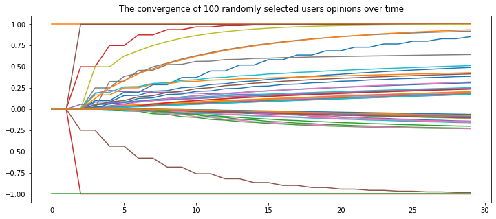

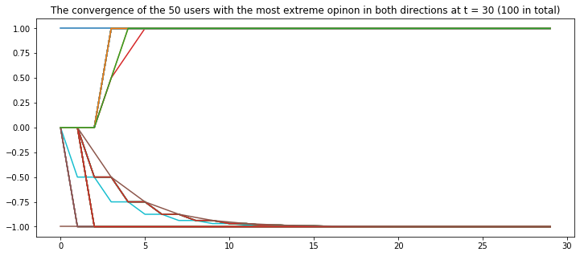

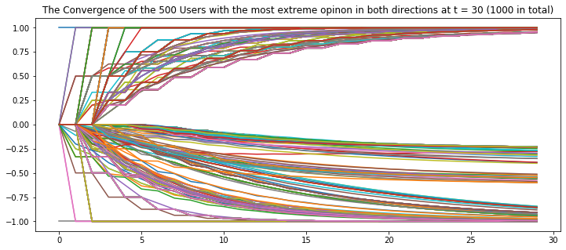

```python
niter = 30
stubborn = [1, 26]
u = [1,-1]
averaging_dynamics_time_series = average_dynamics(stubborn, u, P,niter)
averaging_dynamics_results = averaging_dynamics_time_series[:,-1].tolist()


# Picks some random or specified users from the averaging dynamics time series and plots how their
# opinions change with time
d_100_top_bot = pick_samples(averaging_dynamics_time_series, averaging_dynamics_results, 50, 50)
d_100_rand_top_bot = pick_samples(averaging_dynamics_time_series, averaging_dynamics_results, 500, 500)
d_100_rand = pick_samples(averaging_dynamics_time_series, averaging_dynamics_results, 0, 50,True)

plt.figure(1, figsize = (12,5))
plt.plot(np.arange(0, 30), d_100_rand.transpose())
plt.title('The convergence of 100 randomly selected users opinions over time')

plt.figure(2, figsize = (12,5))
plt.plot(np.arange(0, 30), d_100_top_bot.transpose())
plt.title('The convergence of the 50 users with the most extreme opinon in both directions at t = 30 (100 in total)')

plt.figure(3, figsize = (12,5))
plt.plot(np.arange(0, 30), d_100_rand_top_bot.transpose())
plt.title('The Convergence of the 500 Users with the most extreme opinon in both directions at t = 30 (1000 in total)')

plt.show()
```

\pagebreak

Down below is the plots from the simulated the discrete-time consensus algorithm with [26, 106] as the stubborn nodes and u = [1, -1].

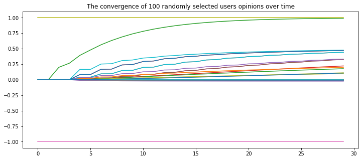

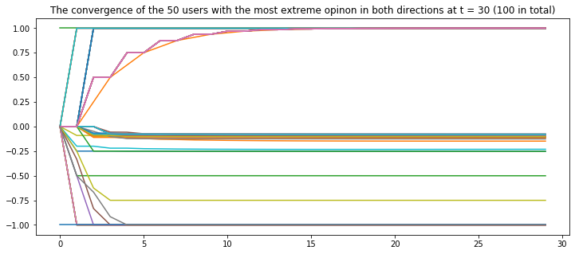

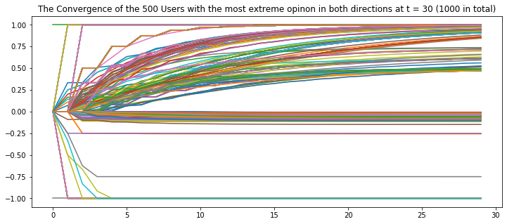

```python
# Choose the number of iterations, the stubborn nodes and their values.
niter = 30
stubborn = [26, 106]
u = [1,-1]
averaging_dynamics_time_series = average_dynamics(stubborn, u, P,niter)
averaging_dynamics_results = averaging_dynamics_time_series[:,-1].tolist()

# Picks some random or specified users from the averaging dynamics time series and plots how their
# opinions change with time
d_100_top_bot = pick_samples(averaging_dynamics_time_series, averaging_dynamics_results, 50, 50)
d_100_rand_top_bot = pick_samples(averaging_dynamics_time_series, averaging_dynamics_results, 500, 500)
d_100_rand = pick_samples(averaging_dynamics_time_series, averaging_dynamics_results, 0, 50,True)

plt.figure(1, figsize = (12,5))
plt.plot(np.arange(0, 30), d_100_rand.transpose())
plt.title('The convergence of 100 randomly selected users opinions over time')

plt.figure(2, figsize = (12,5))
plt.plot(np.arange(0, 30), d_100_top_bot.transpose())
plt.title('The convergence of the 50 users with the most extreme opinon in both directions at t = 30 (100 in total)')

plt.figure(3, figsize = (12,5))
plt.plot(np.arange(0, 30), d_100_rand_top_bot.transpose())
plt.title('The Convergence of the 500 Users with the most extreme opinon in both directions at t = 30 (1000 in total)')

plt.show()
```

It is rather evident from these plots that a node with a higher pageRank is more successful at carrying out public opinion.

\pagebreak

### Opinion Distribution Plots

[figure not shown]

```python
bin_size = 100
f, axs = plt.subplots(3,3,figsize=(15,15))

plt.subplot(3, 3, 1)
plt.hist(averaging_dynamics_results1, bins =bin_size, density=1)
plt.title('High PageRank: 1 - High PageRank: 0')
plt.ylabel('%')
plt.xlabel('Opinion')

plt.subplot(3, 3, 4)
plt.hist(averaging_dynamics_results2, bins =bin_size, density=True)
plt.title('High PageRank: 1 - Mid PageRank: 0')
plt.ylabel('%')
plt.xlabel('Opinion')

plt.subplot(3, 3, 7)
plt.hist(averaging_dynamics_results3, bins =bin_size, density=True)
plt.title('High PageRank: 1 - Low PageRank: 0')
plt.ylabel('%')
plt.xlabel('Opinion')

plt.subplot(3, 3, 2)
plt.hist(averaging_dynamics_results4, bins =bin_size, density=True)
plt.title('Mid PageRank: 1 - High PageRank: 0')
plt.ylabel('%')
plt.xlabel('Opinion')

plt.subplot(3, 3, 5)
plt.hist(averaging_dynamics_results5, bins =bin_size, density=True)
plt.title('Mid PageRank: 1 - Mid PageRank: 0')
plt.ylabel('%')
plt.xlabel('Opinion')

plt.subplot(3, 3, 8)
plt.hist(averaging_dynamics_results6, bins =bin_size, density=True)
plt.title('Mid PageRank: 1 - Low PageRank: 0')
plt.ylabel('%')
plt.xlabel('Opinion')

plt.subplot(3, 3, 3)
plt.hist(averaging_dynamics_results7, bins =bin_size, density=True)
plt.title('Low PageRank: 1 - High PageRank: 0')
plt.ylabel('%')
plt.xlabel('Opinion')

plt.subplot(3, 3, 6)
plt.hist(averaging_dynamics_results8, bins =bin_size, density=True)
plt.title('Low PageRank: 1 - Low PageRank: 0')
plt.ylabel('%')
plt.xlabel('Opinion')

plt.subplot(3, 3, 9)
plt.hist(averaging_dynamics_results9, bins =bin_size, density=True)
plt.title('Low PageRank: 1 - Low PageRank: 0')
plt.ylabel('%')
plt.xlabel('Opinion')

plt.show()
```

As can be seen in the the opinion distribution plots above, the mass of the probabilty moves to the right, the higher the pageRank the stubborn node with opinion 1 has. Analogously the mass of the probabilty "remains" to the left (remember that we initialize all the regular nodes to have opinion 0 here), the higher the pageRank the stubborn node with opinion 0 has.

This property is very nice to see as it is also rather intuative that a stubborn node is more successful to draw probability mass to their opinion if they have a high pageRank.